```python
# Import the libraries
import os
import pandas as pd
import matplotlib.pyplot as plt
import seaborn as sns
import numpy as np
```

# Basic info of the dataset

```python
# Loading the dataset
data = pd.read_csv("Marketing_train.csv")
data.info()
```

```
<class 'pandas.core.frame.DataFrame'>
RangeIndex: 7414 entries, 0 to 7413
Data columns (total 20 columns):
 #   Column          Non-Null Count  Dtype
---  ------          --------------  -----
 0   custAge         5610 non-null   float64
 1   profession      7414 non-null   object
 2   marital         7414 non-null   object
 3   schooling       5259 non-null   object
 4   default         7414 non-null   object
 5   housing         7414 non-null   object
 6   loan            7414 non-null   object
 7   contact         7414 non-null   object
 8   month           7414 non-null   object
 9   day_of_week     6703 non-null   object
 10  campaign        7414 non-null   int64
 11  pdays           7414 non-null   int64
 12  previous        7414 non-null   int64
 13  poutcome        7414 non-null   object
 14  emp.var.rate    7414 non-null   float64
 15  cons.price.idx  7414 non-null   float64
 16  cons.conf.idx   7414 non-null   float64
 17  euribor3m       7414 non-null   float64
 18  nr.employed     7414 non-null   float64
 19  responded       7414 non-null   object
dtypes: float64(6), int64(3), object(11)
memory usage: 1.1+ MB
```

```python
data.describe()
```

|  | custAge | campaign | pdays | previous | emp.var.rate | cons.price.idx | cons.conf.idx | euribor3m | nr.employed |
| --- | --- | --- | --- | --- | --- | --- | --- | --- | --- |
| count | 5610.000000 | 7414.000000 | 7414.000000 | 7414.000000 | 7414.000000 | 7414.000000 | 7414.000000 | 7414.000000 | 7414.000000 |
| mean | 40.009804 | 2.518344 | 960.024548 | 0.184111 | 0.052091 | 93.570708 | -40.561316 | 3.583141 | 5165.224251 |
| std | 10.574616 | 2.695055 | 192.845029 | 0.516775 | 1.568399 | 0.578345 | 4.649800 | 1.744865 | 73.108669 |
| min | 18.000000 | 1.000000 | 0.000000 | 0.000000 | -3.400000 | 92.201000 | -50.800000 | 0.634000 | 4963.600000 |
| 25% | 32.000000 | 1.000000 | 999.000000 | 0.000000 | -1.800000 | 93.075000 | -42.700000 | 1.334000 | 5099.100000 |
| 50% | 38.000000 | 2.000000 | 999.000000 | 0.000000 | 1.100000 | 93.444000 | -41.800000 | 4.857000 | 5191.000000 |
| 75% | 47.000000 | 3.000000 | 999.000000 | 0.000000 | 1.400000 | 93.994000 | -36.400000 | 4.961000 | 5228.100000 |
| max | 94.000000 | 40.000000 | 999.000000 | 6.000000 | 1.400000 | 94.767000 | -26.900000 | 5.045000 | 5228.100000 |

```python
data.head()
```

|  | custAge | profession | marital | schooling | default | housing | loan | contact | month | day_of_week | campaign | pdays | previous | poutcome | emp.var.rate | cons.price.idx | cons.conf.idx | euribor3m | nr.employed | responded |
| --- | --- | --- | --- | --- | --- | --- | --- | --- | --- | --- | --- | --- | --- | --- | --- | --- | --- | --- | --- | --- |
| 0 | 55.0 | admin. | single | university.degree | unknown | no | no | cellular | nov | mon | 1 | 999 | 0 | nonexistent | -0.1 | 93.200 | -42.0 | 4.191 | 5195.8 | no |
| 1 | NaN | blue-collar | married | NaN | no | no | no | cellular | jul | mon | 1 | 999 | 0 | nonexistent | 1.4 | 93.918 | -42.7 | 4.960 | 5228.1 | no |
| 2 | 42.0 | technician | married | high.school | no | no | no | telephone | may | mon | 1 | 999 | 0 | nonexistent | 1.1 | 93.994 | -36.4 | 4.857 | 5191.0 | no |
| 3 | 55.0 | management | divorced | NaN | unknown | yes | yes | cellular | jul | wed | 2 | 999 | 0 | nonexistent | 1.4 | 93.918 | -42.7 | 4.962 | 5228.1 | no |
| 4 | NaN | admin. | divorced | university.degree | no | yes | no | cellular | may | tue | 5 | 999 | 1 | failure | -1.8 | 92.893 | -46.2 | 1.291 | 5099.1 | no |

```python
print(data["profession"].value_counts())
print("*"*25)
print(data["marital"].value_counts())
print("*"*25)
print(data["schooling"].value_counts())
```

```
admin.           1885
blue-collar      1665
technician       1212
services          719
management        536
retired           307
entrepreneur      275
self-employed     248
housemaid         187
unemployed        173
student           146
unknown            61
Name: profession, dtype: int64
married     4445
single      2118
divorced     843
unknown        8
Name: marital, dtype: int64
university.degree      1554
high.school            1216
basic.9y                784
professional.course     664
basic.4y                534
basic.6y                275
unknown                 231
illiterate                1
Name: schooling, dtype: int64
```

```python
print(data["responded"].value_counts())
```

```
no     6574
yes     840
Name: responded, dtype: int64
```

From the above distribution we can be sure that the data is imbalanced, as the number of "no"s are also 8 times the number of "yes"

# Exploratory Data Analysis

### Distribution of Class variable

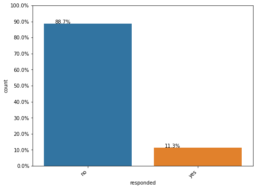

```python
plt.figure(figsize=(8,6))
Y = data["responded"]
total = len(Y)*1.
ax=sns.countplot(x="responded", data=data)
for p in ax.patches:
    ax.annotate('{:.1f}%'.format(100*p.get_height()/total), (p.get_x()+0.1, p.get_height()+5))

ax.yaxis.set_ticks(np.linspace(0, total, 11))
  #adjust the ticklabel to the desired format, without changing the position of the ticks.
ax.set_yticklabels(map('{:.1f}%'.format, 100*ax.yaxis.get_majorticklocs()/total))
ax.set_xticklabels(ax.get_xticklabels(), rotation=40, ha="right")
  # ax.legend(labels=["no","yes"])
plt.show()
```

# Univariate Analysis

```python
def countplot(label, dataset):
    plt.figure(figsize=(15,10))
    Y = data[label]
    total = len(Y)*1.
    ax=sns.countplot(x=label, data=dataset)
    for p in ax.patches:
        ax.annotate('{:.1f}%'.format(100*p.get_height()/total), (p.get_x()+0.1, p.get_height()+5))

  #put 11 ticks (therefore 10 steps), from 0 to the total number of rows in the dataframe
    ax.yaxis.set_ticks(np.linspace(0, total, 11))
  #adjust the ticklabel to the desired format, without changing the position of the ticks.
    ax.set_yticklabels(map('{:.1f}%'.format, 100*ax.yaxis.get_majorticklocs()/total))
    ax.set_xticklabels(ax.get_xticklabels(), rotation=40, ha="right")
  # ax.legend(labels=["no","yes"])
    plt.show()
```

```python
%matplotlib inline

def countplot_withY(label, dataset):
    plt.figure(figsize=(20,10))
    Y = data[label]
    total = len(Y)*1.
    ax=sns.countplot(x=label, data=dataset, hue="responded")
    for p in ax.patches:
        ax.annotate('{:.1f}%'.format(100*p.get_height()/total), (p.get_x()+0.1, p.get_height()+5))

  #put 11 ticks (therefore 10 steps), from 0 to the total number of rows in the dataframe
    ax.yaxis.set_ticks(np.linspace(0, total, 11))
  #adjust the ticklabel to the desired format, without changing the position of the ticks.
    ax.set_yticklabels(map('{:.1f}%'.format, 100*ax.yaxis.get_majorticklocs()/total))
    ax.set_xticklabels(ax.get_xticklabels(), rotation=40, ha="right")
  # ax.legend(labels=["no","yes"])
    plt.show()
```

## Feature: Job (Categorical variable)

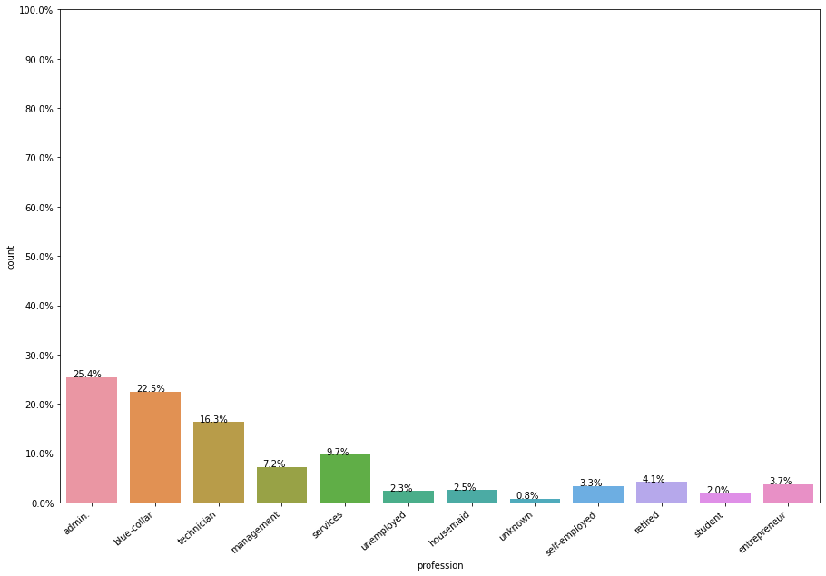

```python
countplot("profession", data)
```

From the above distribution we can see that most of the customers have jobs as "admin", "blue-collar" or "technician". One interesting thing to find out would be to see the distribution for each classes as well. For example, how many people who work as an admin have subscribed a term deposit.

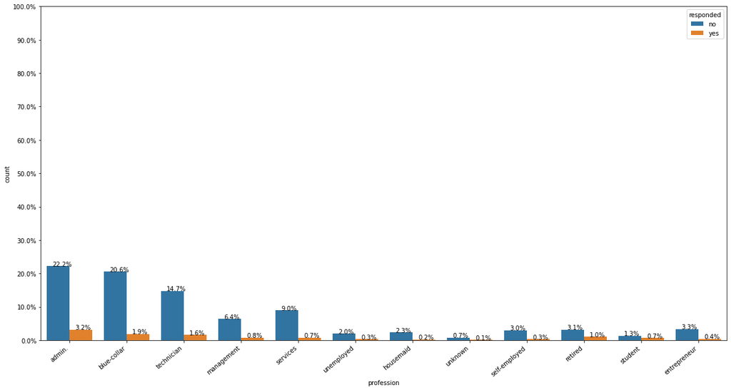

```python
countplot_withY("profession", data)
```

From the above plot, we can see that the customers who have a job of admin have the highest rate of subscribing a term deposit, but they are also the highest when it comes to not subscribing. This is simply because we have more customers working as admin than any other profession.

We can find out the odds or ratio of subscribing and not subscribing based on the profession, to find out which profession has the highest odds of subscribing given the data. At this point we are not sure if there is any correlation between job and target variable.

**Idea:** If we find that odds of one profession subscribing is greater than other job, we can use the odds or log(odds) as a feature by replacing jobs field with the odds, instead of doing one hot encoding.

## Feature: Marital (Categorical feature)

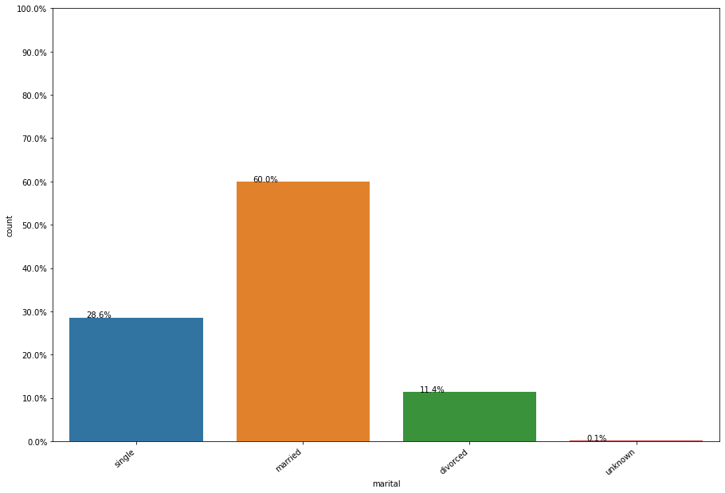

```python
countplot("marital", data)
```

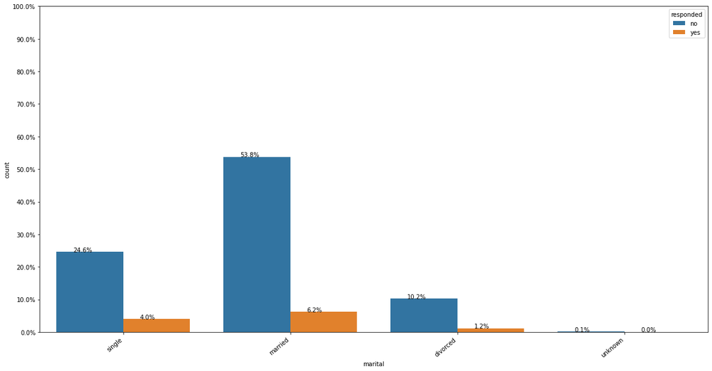

```python
countplot_withY("marital", data)
```

## Feature: default (categorical)

This is a categorical feature which means "has credit in default", with the values "yes" and "no" and "unknown".

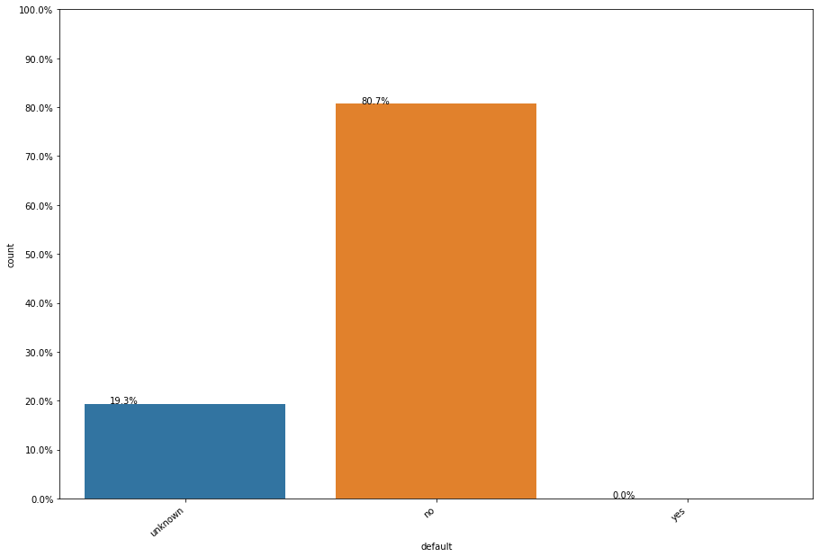

```python
countplot("default", data)
```

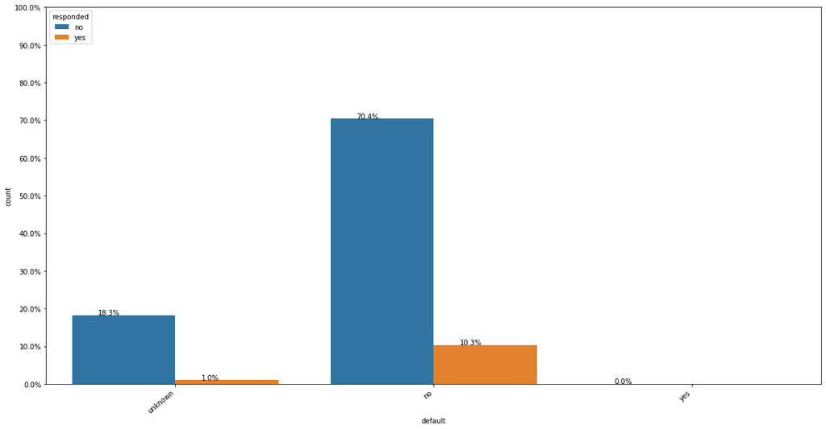

```python
countplot_withY("default", data)
```

## Feature: Education

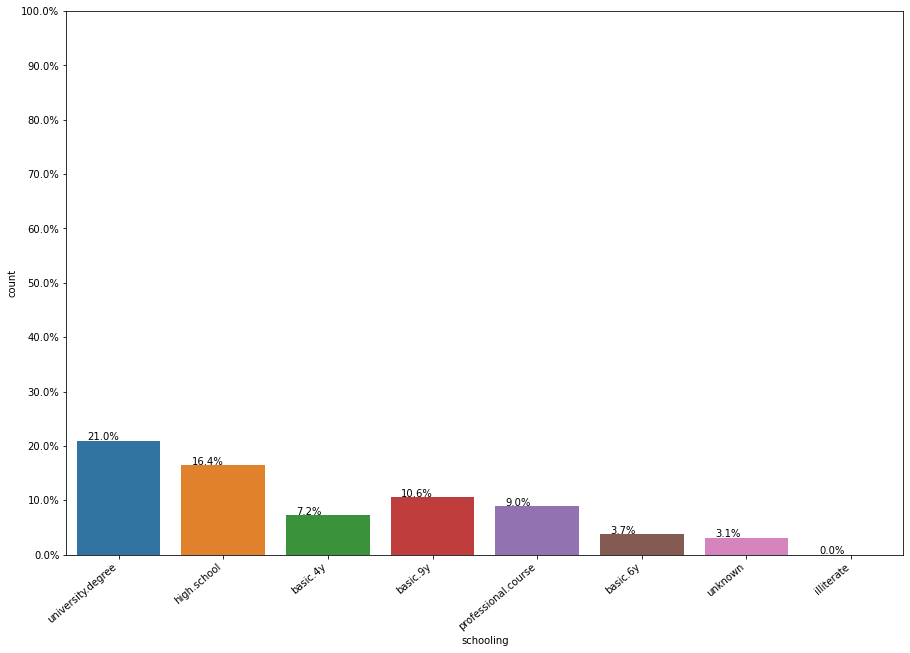

```python
countplot("schooling",data)
```

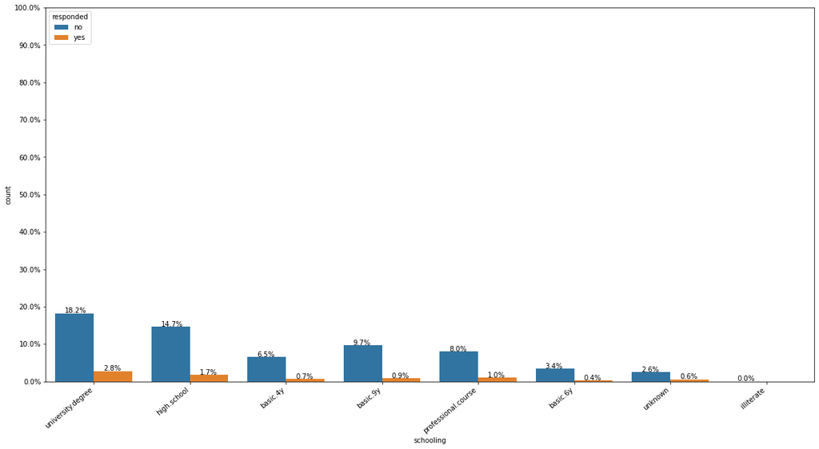

```python
countplot_withY("schooling", data)
```

## Feature: housing (Categorical)

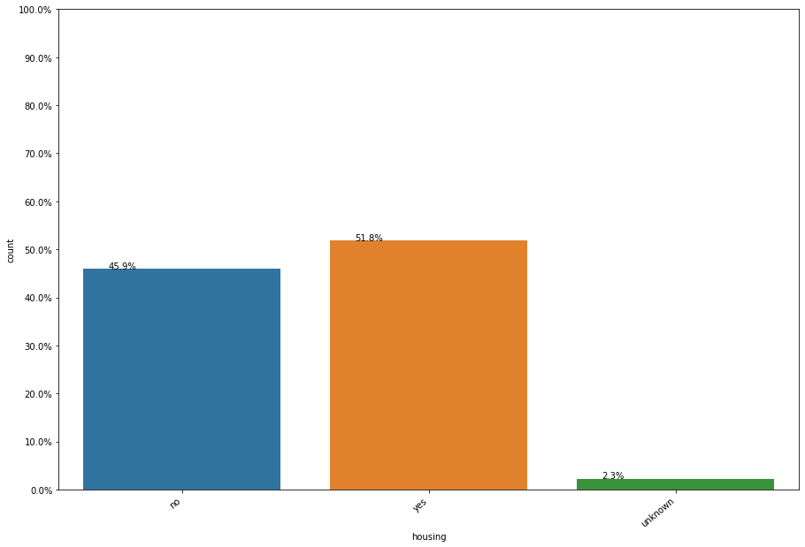

```python
countplot("housing", data)
```

Majority of the customers have a housing loan.

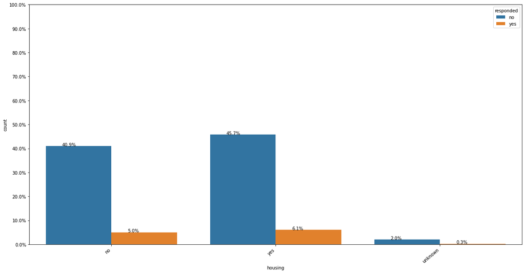

```python
countplot_withY("housing", data)
```

## Feature: loan (Categorical)

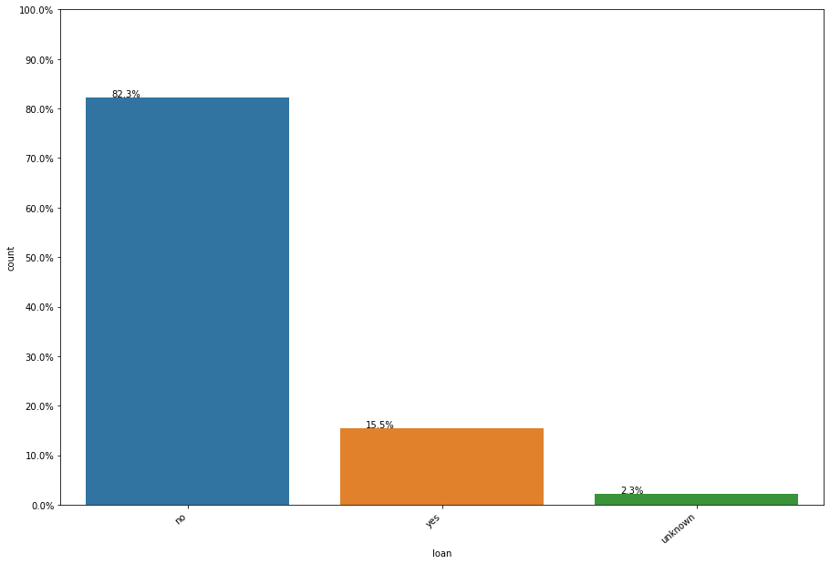

```python
countplot("loan", data)
```

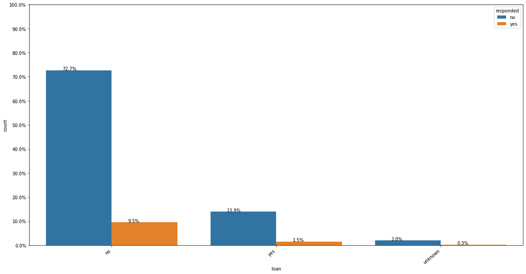

```python
countplot_withY("loan", data)
```

## Feature: contact (Categorical)

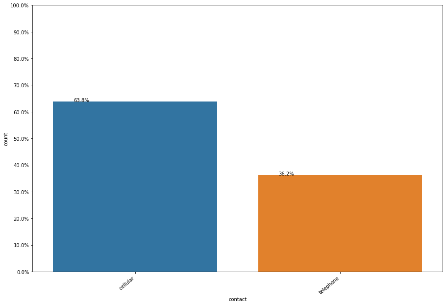

```python
countplot("contact", data)
```

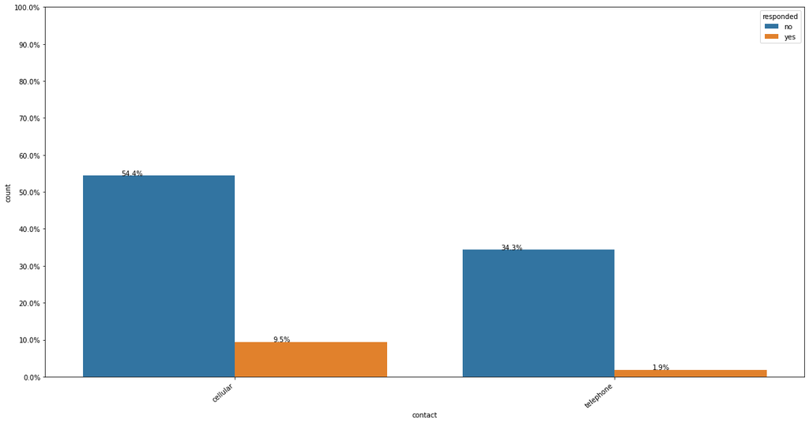

```python
countplot_withY("contact", data)
```

## Feature: month (Categorical)

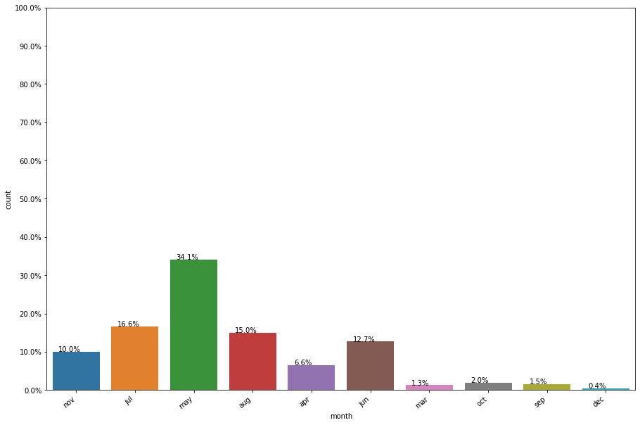

```python
countplot("month", data)
```

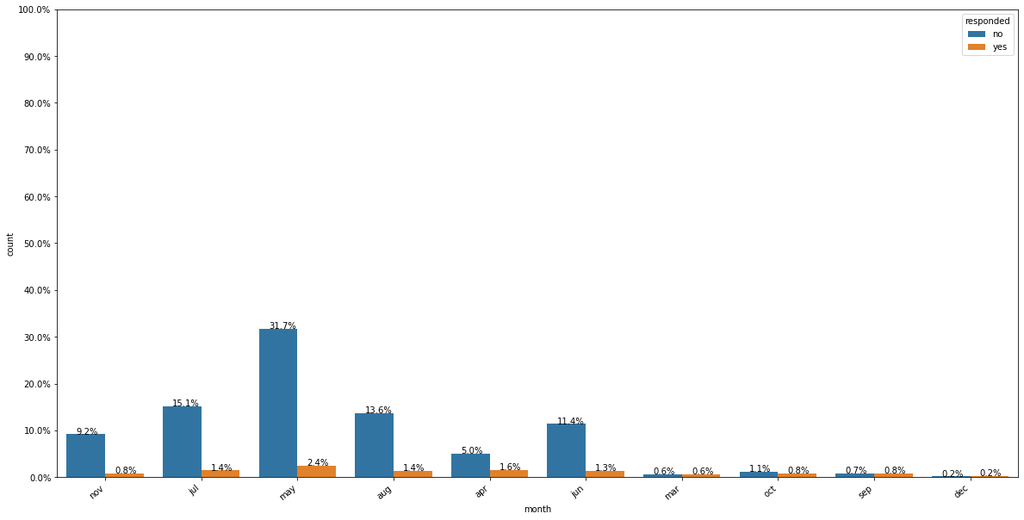

```python
countplot_withY("month", data)
```

## Feature: day_of_week (Categorical)

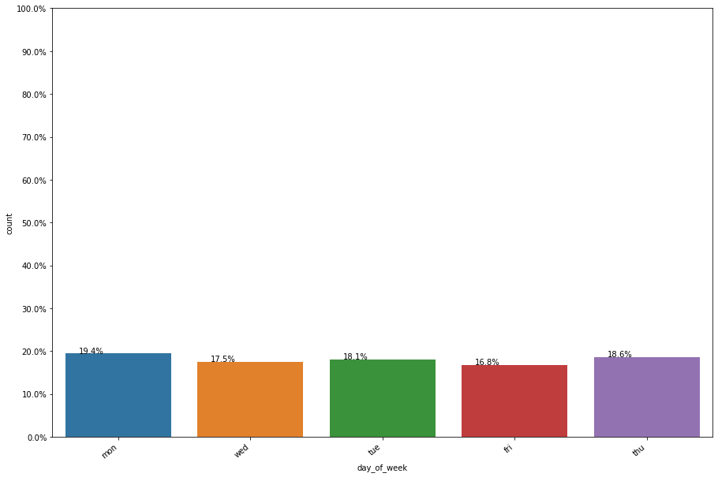

```python
countplot("day_of_week", data)
```

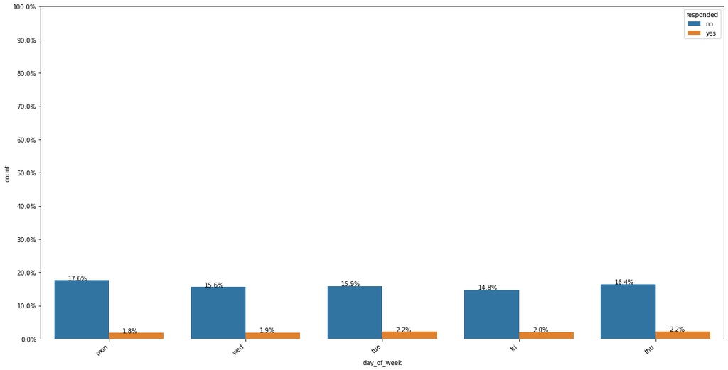

```python
countplot_withY("day_of_week", data)
```

The day of the week seems to be irrelevent as we have the same amount of data for all the days of the week, and no:yes ratio is also almost same.

## Feature: poutcome (Categorical)

This feature indicates the outcome of the previous marketing campaign

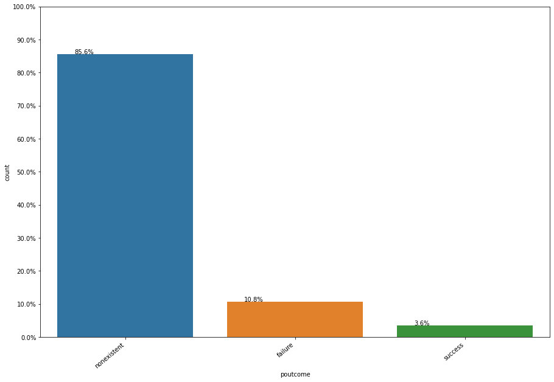

```python
countplot("poutcome", data)
```

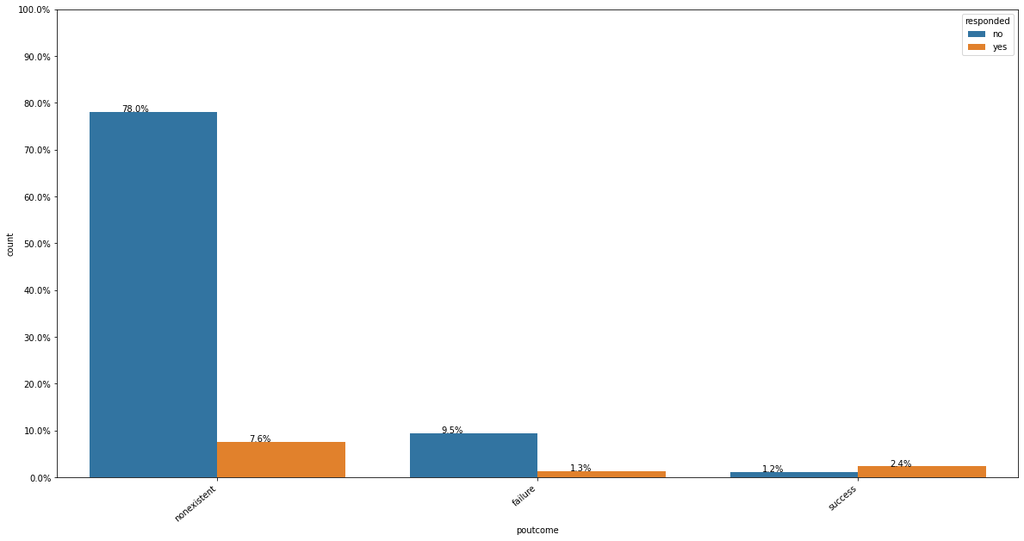

```python
countplot_withY("poutcome", data)
```

## Feature: Age (Numeric)

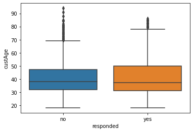

```python
%matplotlib inline
sns.boxplot(data=data, x="responded", y="custAge")
plt.show()
```

From the above boxplot we know that for both the customers that subscibed or didn't subscribe a term deposit, has a median age of around 38-40. And the boxplot for both the classes overlap quite a lot, which means that age isn't necessarily a good indicator for which customer will subscribe and which customer will not.

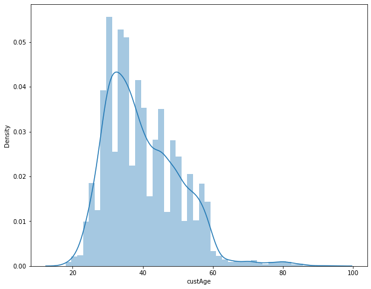

```python
plt.figure(figsize=(10,8))
sns.distplot(data["custAge"])
```

As we can see in the above distribution also, that most of the customers are in the age range of 20-60.

## Feature: campaign (numeric)

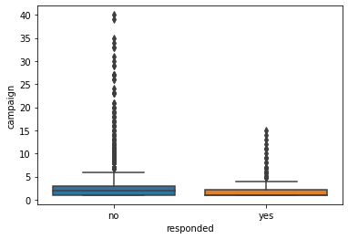

```python
%matplotlib inline
sns.boxplot(data=data, x="responded", y="campaign")
plt.show()
```

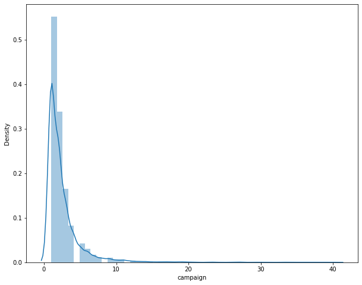

```python
%matplotlib inline
plt.figure(figsize=(10,8))
sns.distplot(data["campaign"])
plt.show()
```

## Feature: pdays (numeric)

```python
data["pdays"].unique()
```

```
array([999,   6,   7,   5,   1,   3,  10,  15,   2,  22,  14,   4,   9,
        11,  12,  13,   8,  16,   0,  17,  21], dtype=int64)
```

```python
data["pdays"].value_counts()
```

```
999    7123
6        85
3        82
4        22
7        15
9        15
2        13
12       11
10        8
5         7
13        6
14        5
11        4
15        4
8         3
1         3
0         2
16        2
17        2
22        1
21        1
Name: pdays, dtype: int64
```

Most of the values are 999, which means that the most of the customers have never been contacted before.

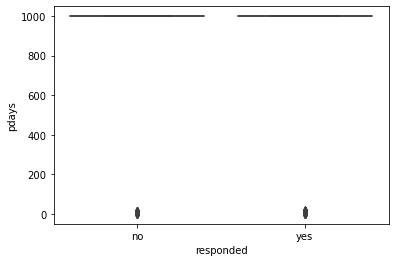

```python
%matplotlib inline
sns.boxplot(data=data, x="responded", y="pdays")
plt.show()
```

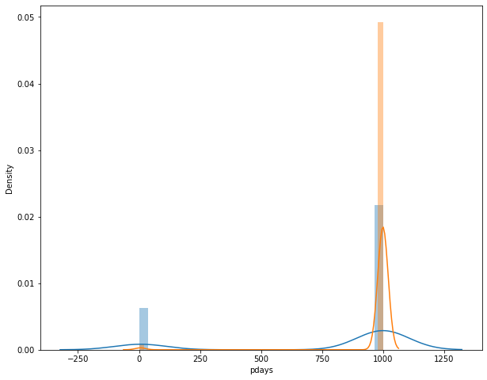

```python
%matplotlib inline
plt.figure(figsize=(10,8))
sns.distplot(data[data["responded"]=="yes"]["pdays"])
sns.distplot(data[data["responded"]=="no"]["pdays"])
plt.show()
```

## Feature: previous (numeric)

```python
data["previous"].unique()
```

```
array([0, 1, 2, 4, 3, 5, 6], dtype=int64)
```

```python
data["previous"].value_counts()
```

```
0    6350
1     855
2     147
3      41
4      13
5       7
6       1
Name: previous, dtype: int64
```

```python
data[data["responded"]=="yes"]["previous"].value_counts()
```

```
0    567
1    176
2     64
3     23
4      6
5      3
6      1
Name: previous, dtype: int64
```

```python
data[data["responded"]=="no"]["previous"].value_counts()
```

```
0    5783
1     679
2      83
3      18
4       7
5       4
Name: previous, dtype: int64
```

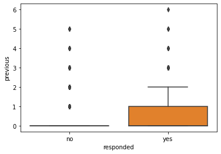

```python
%matplotlib inline
sns.boxplot(data=data, x="responded", y="previous")
plt.show()
```

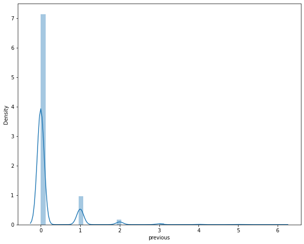

```python
%matplotlib inline
plt.figure(figsize=(10,8))
sns.distplot(data["previous"])
plt.show()
```

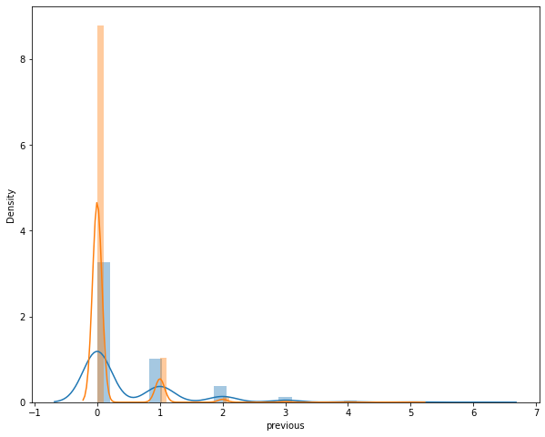

```python
%matplotlib inline
plt.figure(figsize=(10,8))
sns.distplot(data[data["responded"]=="yes"]["previous"])
sns.distplot(data[data["responded"]=="no"]["previous"])
plt.show()
```

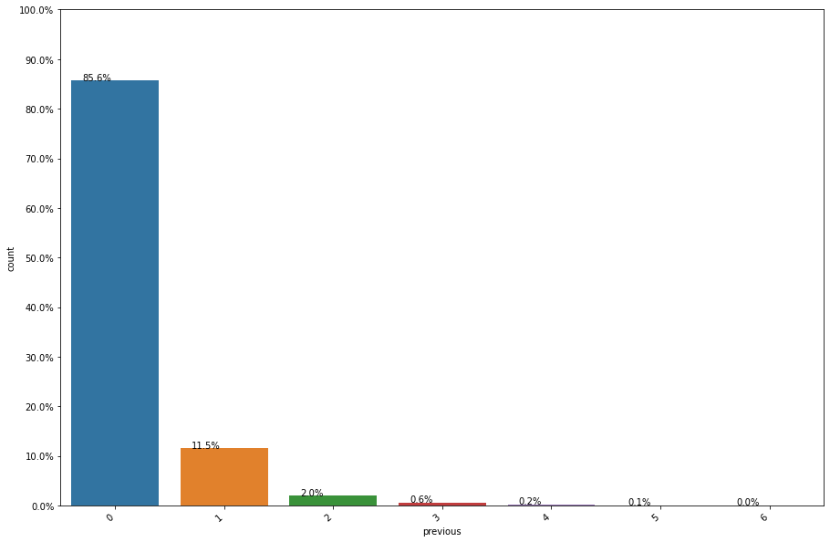

```python
countplot("previous", data)
```

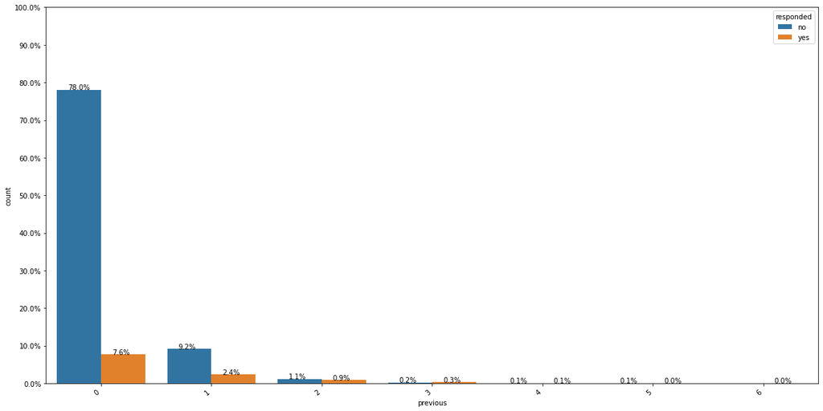

```python
countplot_withY("previous", data)
```